# Using temperature to describe stress

Mikaela M. Provost

7/30/2020

## Goals

Overal goal is to develop a method that defines stress through time based on a time series of temperature. Before running our stress model, I want to calibrate SST to match *in situ* temperature at depth. We have lots of *in situ* data, but we have so much more SST.

What data do we have?

- *In situ* daily temperature observations ( 9/12/2015 – 8/17/2018) in two locations, Morro Prieto and Punta Prieta.
- Daily SST for a longer period of time (2009-2019) in both locations.

Update: randomly select one temperature per day from the 10 min data. Then run slope model on this time series of bottom temperature (instead of using mean daily T).

#### Skip

Calculate the average difference between SST and *in situ* temp

1. Find the average temperature per Julian day (at each site, for *in situ* and for SST).
2. Calculate a smoothed monthly moving average.
3. For each Julian day, calculate the difference between the moving average of SST and *in situ*.
4. Use this daily-offset to adjust daily SST temperatures.

#### 1) Plot the raw temperature at each location.

*In situ* daily temperature is randomly chosen from 10 minute temperature recordings.

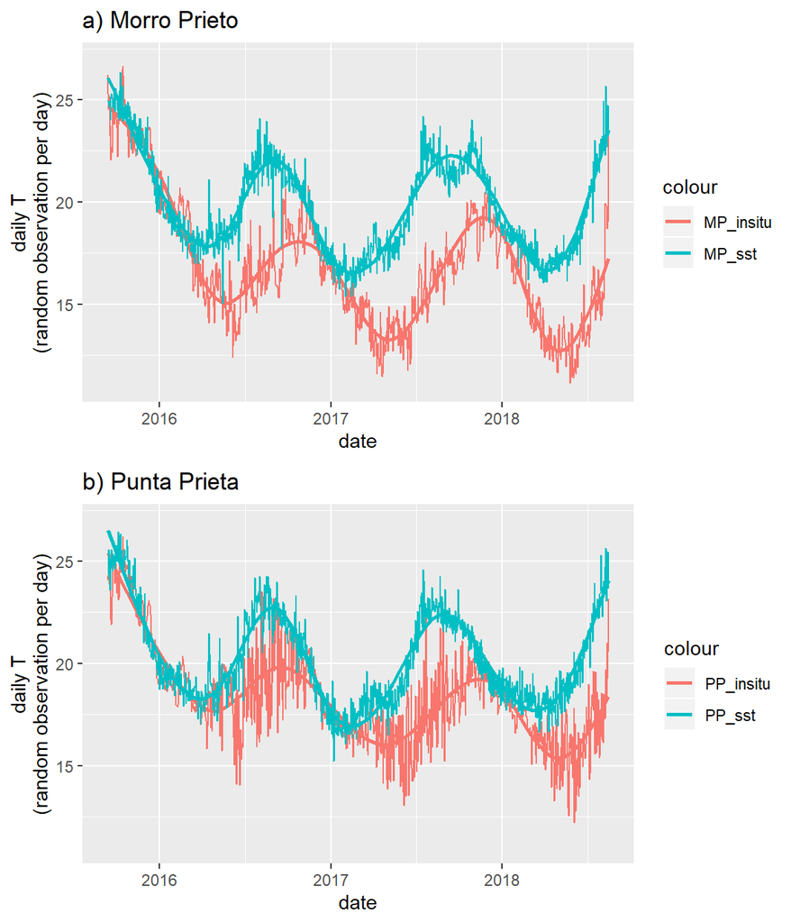

*In situ* daily temperature is average of 10 minute temperature recordings.

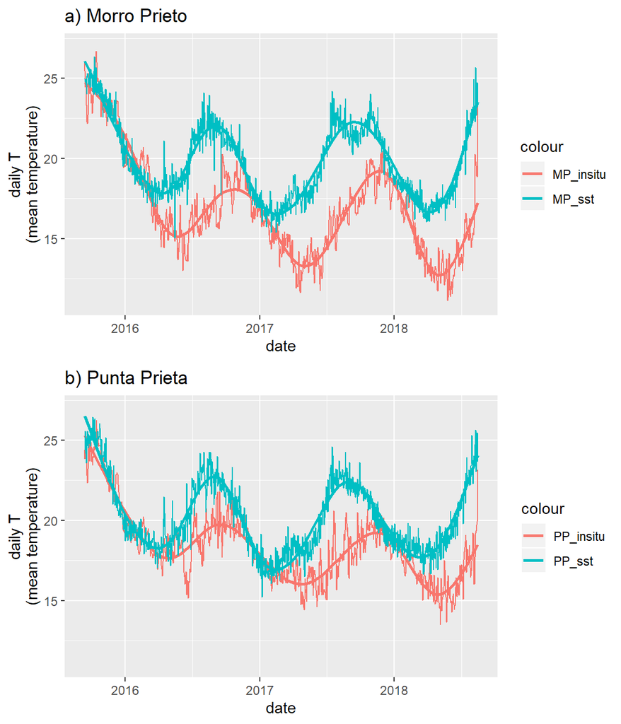

#### 3) Skip

Old stuff: Compare raw SST with the adjusted SST (SST-offset)

#### 4) Skip

Overlay the adjusted SST with *in situ* time series – do they match?

Does the daily SST offset work?

- Sort of. The peaks and troughs appear to line up more closely than the raw SST data
- Mean temperature per day in the adjusted SST time series doesn’t overlap the mean *in situ* throughout the year (this is bad)
- In some years there is better overlap compared to other years.

##### 4 (a,b) Skip

Offset in SST is based on an average of in situ data at both Morro Prieto and Punta Prieta.

#### 5) Skip

Old stuff: Apply stress model to adjusted SST & *in situ* time series

## Apply the stress model on raw SST and *in situ* time series

We run the stress model on raw time series. *In situ* daily time series is not the average daily temperature, daily bottom temperature is randomly selected from the 10 minute data. We did this to have a more direct comparison with daily SST observations.

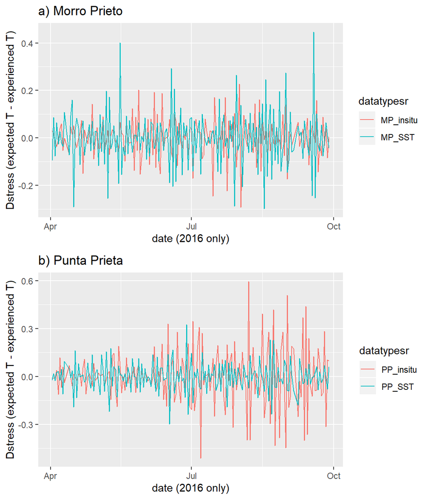

#### Plot stress time series for entire year (2016)

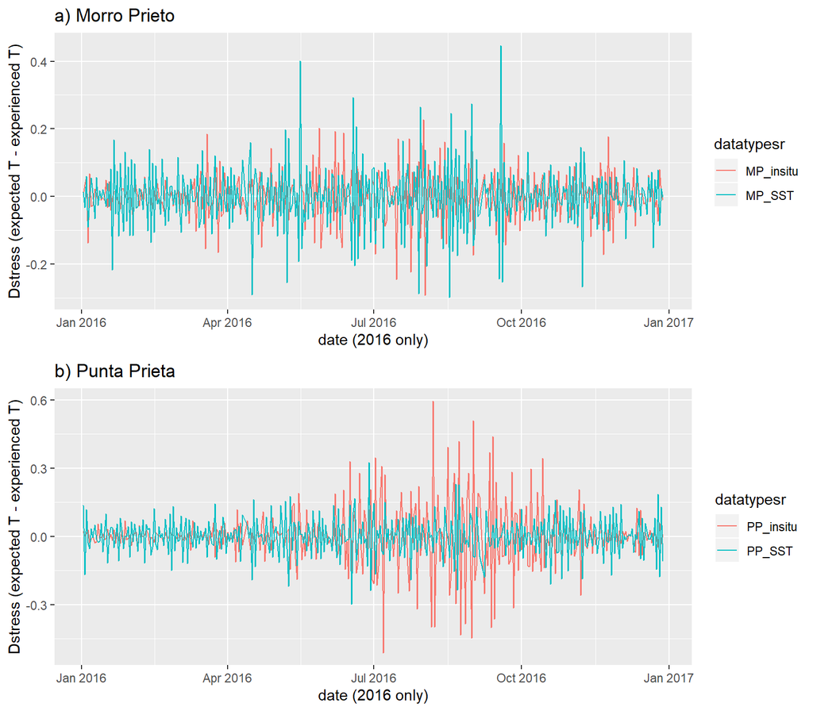

## Time lags between SST and in situ

For one site, plot SST at time *t* on x-axis and in situ temperature at *t+n* day. Here *n* is a number of days into the future from day *t*.

### 1) 30 day time lag

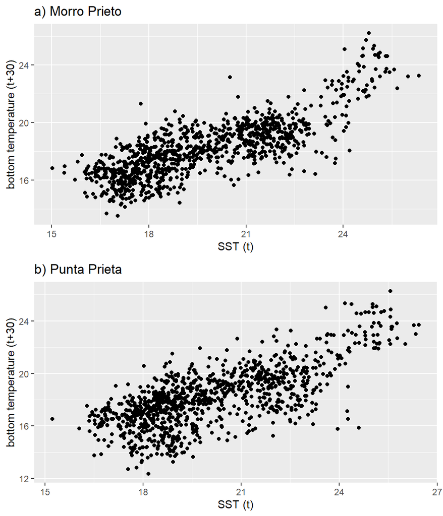

### 2) 45 day time lag

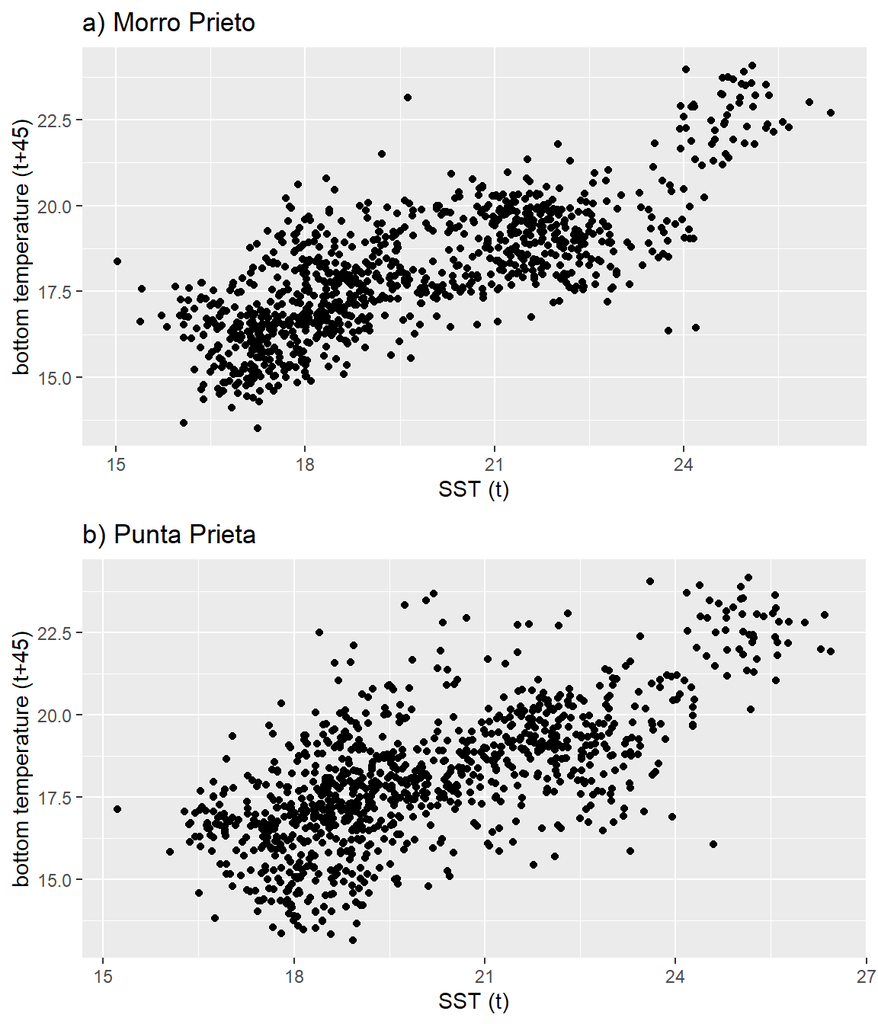